# Crime Analysis in Washington, DC (2023)

Group 1: Naiska, Halima, Vishal, Suraj

2024-10-28

# 1 Introduction

In our project, we aim to investigate crime patterns in Washington, DC, utilizing data from the Open Data DC portal. The dataset, “Crime Incidents in 2023,” comprises 34,215 observations detailing reported crimes, including information on the type of offense, time of occurrence, geographic location, and methods involved.

As individuals, especially students, consider buying a house, renting an apartment, relocating, or traveling, one of the first questions that arise is “Is it safe?”. This concern for safety drives many to seek out neighborhoods with low crime rates before evaluating other factors such as price, amenities, and accessibility. Therefore, understanding crime dynamics is crucial not only for law enforcement but also for residents and potential newcomers to the area.

The primary focus of our analysis is to explore crime density across different areas of Washington, DC, identifying neighborhoods that experience the highest levels of criminal activity. This exploration aims to uncover patterns that can inform law enforcement resource allocation and guide community safety initiatives aimed at crime prevention. By providing insights into crime trends, we hope to empower individuals and families to make informed decisions regarding their living environments.

# 2 Dataset Source

Dataset: [Crime Incidents in 2023](https://opendata.dc.gov/datasets/DCGIS::crime-incidents-in-2023/explore?showTable=true)

This dataset serves as the primary source for our analysis, encompassing 34,215 reported crime incidents in Washington, DC. It includes critical information such as the type of offense, time of occurrence, geographic location, and methods involved. This comprehensive dataset is essential for examining crime patterns and densities across different neighborhoods.

Dataset: [Neighborhood Clusters](https://catalog.data.gov/dataset/neighborhood-clusters/resource/39d2cb14-5d10-4ac2-916e-f5b78670fcb9?inner_span=True)

This dataset provides a mapping of numerical identifiers for neighborhoods to more recognizable names, such as Columbia Heights, Georgetown, and Dupont Circle. By integrating this data, we enhance the interpretability of our analysis, making it easier for stakeholders to understand the geographic context of crime data.

Dataset: [DC Police Stations](https://opendata.dc.gov/datasets/police-stations/explore?showTable=true)

This dataset contains the locations of police stations across Washington, DC. Incorporating this information allows us to analyze the proximity of law enforcement resources to neighborhoods with varying crime rates, offering insights into potential coverage gaps.

# 3 Data Preprocessing

## 3.1 Data Overview

The “Crime Incidents in 2023” dataset had total of 34215 observations and 25 variables.

```r
#Libraries utilized to complete the project
library(dplyr)
library(ezids)
library(lubridate)
library(tigris)
library(ggthemes)
library(ggplot2)
library(sf)
library(leaflet)
library(gridExtra)
library(patchwork)
library(geosphere)
```

```r
# Loading the crime dataset
crime_data <- read.csv('Crime_Incidents_in_2023.csv')
xkabledplyhead(crime_data, title = 'First 5 Rows of the Crime Dataset')
```

First 5 Rows of the Crime Dataset

| X | Y | CCN | REPORT_DAT | SHIFT | METHOD | OFFENSE | BLOCK | XBLOCK | YBLOCK | WARD | ANC | DISTRICT | PSA | NEIGHBORHOOD_CLUSTER | BLOCK_GROUP | CENSUS_TRACT | VOTING_PRECINCT | LATITUDE | LONGITUDE | BID | START_DATE | END_DATE | OBJECTID | OCTO_RECORD_ID |
| --- | --- | --- | --- | --- | --- | --- | --- | --- | --- | --- | --- | --- | --- | --- | --- | --- | --- | --- | --- | --- | --- | --- | --- | --- |
| 396736 | 140470 | 23120415 | 2023/07/25 05:09:14+00 | MIDNIGHT | OTHERS | ROBBERY | 1600 - 1699 BLOCK OF PARK ROAD NW | 396736 | 140470 | 1 | 1D | 3 | 302 | Cluster 2 | 002702 1 | 2702 | Precinct 40 | 38.9 | -77 |  | 2023/07/25 04:10:00+00 | 2023/07/25 04:15:00+00 | 5.96e+08 | NA |
| 397177 | 146810 | 23047033 | 2023/03/27 06:12:11+00 | MIDNIGHT | GUN | ROBBERY | 8129 - 8148 BLOCK OF EASTERN AVENUE NW | 397177 | 146810 | 4 | 4A | 4 | 401 | Cluster 16 | 001600 1 | 1600 | Precinct 62 | 39.0 | -77 |  | 2023/03/27 04:38:00+00 |  | 5.96e+08 | NA |
| 398478 | 137857 | 23187303 | 2023/11/15 19:31:25+00 | DAY | OTHERS | THEFT/OTHER | 400 - 499 BLOCK OF O STREET NW | 398478 | 137857 | 2 | 2G | 3 | 308 | Cluster 7 | 004801 3 | 4801 | Precinct 18 | 38.9 | -77 |  | 2023/11/06 21:25:00+00 | 2023/11/06 21:30:00+00 | 5.96e+08 | NA |
| 396659 | 137377 | 23055316 | 2023/04/10 06:13:40+00 | MIDNIGHT | OTHERS | THEFT F/AUTO | 1100 - 1129 BLOCK OF 17TH STREET NW | 396659 | 137377 | 2 | 2C | 2 | 207 | Cluster 6 | 010700 1 | 10700 | Precinct 17 | 38.9 | -77 | GOLDEN TRIANGLE | 2023/04/10 05:50:00+00 | 2023/04/10 05:55:00+00 | 5.96e+08 | NA |
| 397874 | 139955 | 23056311 | 2023/04/11 23:18:47+00 | EVENING | OTHERS | MOTOR VEHICLE THEFT | 700 - 999 BLOCK OF HOBART PLACE NW | 397874 | 139955 | 1 | 1E | 3 | 304 | Cluster 2 | 003100 1 | 3100 | Precinct 37 | 38.9 | -77 |  | 2023/04/10 17:26:00+00 | 2023/04/11 23:00:00+00 | 5.96e+08 | NA |

```r
str(crime_data)
```

```
## 'data.frame':    34215 obs. of  25 variables:
##  $ X                   : num  396736 397177 398478 396659 397874 ...
##  $ Y                   : num  140470 146810 137857 137377 139955 ...
##  $ CCN                 : int  23120415 23047033 23187303 23055316 23056311 23156424 23156932 23131286 23087621 23130132 ...
##  $ REPORT_DAT          : chr  "2023/07/25 05:09:14+00" "2023/03/27 06:12:11+00" "2023/11/15 19:31:25+00" "2023/04/10 06:13:40+00" ...
##  $ SHIFT               : chr  "MIDNIGHT" "MIDNIGHT" "DAY" "MIDNIGHT" ...
##  $ METHOD              : chr  "OTHERS" "GUN" "OTHERS" "OTHERS" ...
##  $ OFFENSE             : chr  "ROBBERY" "ROBBERY" "THEFT/OTHER" "THEFT F/AUTO" ...
##  $ BLOCK               : chr  "1600 - 1699 BLOCK OF PARK ROAD NW" "8129  - 8148 BLOCK OF EASTERN AVENUE NW" "400 - 499 BLOCK OF O STREET NW" "1100 - 1129 BLOCK OF 17TH STREET NW" ...
##  $ XBLOCK              : num  396736 397177 398478 396659 397874 ...
##  $ YBLOCK              : num  140470 146810 137857 137377 139955 ...
##  $ WARD                : int  1 4 2 2 1 8 6 2 2 1 ...
##  $ ANC                 : chr  "1D" "4A" "2G" "2C" ...
##  $ DISTRICT            : int  3 4 3 2 3 7 1 1 2 3 ...
##  $ PSA                 : int  302 401 308 207 304 701 103 101 209 302 ...
##  $ NEIGHBORHOOD_CLUSTER: chr  "Cluster 2" "Cluster 16" "Cluster 7" "Cluster 6" ...
##  $ BLOCK_GROUP         : chr  "002702 1" "001600 1" "004801 3" "010700 1" ...
##  $ CENSUS_TRACT        : int  2702 1600 4801 10700 3100 7503 10500 5801 10100 2702 ...
##  $ VOTING_PRECINCT     : chr  "Precinct 40" "Precinct 62" "Precinct 18" "Precinct 17" ...
##  $ LATITUDE            : num  38.9 39 38.9 38.9 38.9 ...
##  $ LONGITUDE           : num  -77 -77 -77 -77 -77 ...
##  $ BID                 : chr  "" "" "" "GOLDEN TRIANGLE" ...
##  $ START_DATE          : chr  "2023/07/25 04:10:00+00" "2023/03/27 04:38:00+00" "2023/11/06 21:25:00+00" "2023/04/10 05:50:00+00" ...
##  $ END_DATE            : chr  "2023/07/25 04:15:00+00" "" "2023/11/06 21:30:00+00" "2023/04/10 05:55:00+00" ...
##  $ OBJECTID            : int  596090380 596090385 596090386 596090387 596090388 596090389 596090390 596090393 596090394 596090395 ...
##  $ OCTO_RECORD_ID      : logi  NA NA NA NA NA NA ...
```

```r
xkablesummary(crime_data, title = 'Summary Statistics of the Crime Dataset')
```

Summary Statistics of the Crime Dataset

|  | X | Y | CCN | REPORT_DAT | SHIFT | METHOD | OFFENSE | BLOCK | XBLOCK | YBLOCK | WARD | ANC | DISTRICT | PSA | NEIGHBORHOOD_CLUSTER | BLOCK_GROUP | CENSUS_TRACT | VOTING_PRECINCT | LATITUDE | LONGITUDE | BID | START_DATE | END_DATE | OBJECTID | OCTO_RECORD_ID |
| --- | --- | --- | --- | --- | --- | --- | --- | --- | --- | --- | --- | --- | --- | --- | --- | --- | --- | --- | --- | --- | --- | --- | --- | --- | --- |
| Min | Min. :390262 | Min. :127432 | Min. : 5008224 | Length:34215 | Length:34215 | Length:34215 | Length:34215 | Length:34215 | Min. :390262 | Min. :127432 | Min. :1.00 | Length:34215 | Min. :1.0 | Min. :101 | Length:34215 | Length:34215 | Min. : 101 | Length:34215 | Min. :38.8 | Min. :-77.1 | Length:34215 | Length:34215 | Length:34215 | Min. :5.96e+08 | Mode:logical |
| Q1 | 1st Qu.:397265 | 1st Qu.:136120 | 1st Qu.:23060944 | Class :character | Class :character | Class :character | Class :character | Class :character | 1st Qu.:397265 | 1st Qu.:136120 | 1st Qu.:2.00 | Class :character | 1st Qu.:2.0 | 1st Qu.:208 | Class :character | Class :character | 1st Qu.: 3701 | Class :character | 1st Qu.:38.9 | 1st Qu.:-77.0 | Class :character | Class :character | Class :character | 1st Qu.:5.96e+08 | NA’s:34215 |
| Median | Median :399074 | Median :137847 | Median :23117679 | Mode :character | Mode :character | Mode :character | Mode :character | Mode :character | Median :399074 | Median :137847 | Median :5.00 | Mode :character | Median :4.0 | Median :401 | Mode :character | Mode :character | Median : 7202 | Mode :character | Median :38.9 | Median :-77.0 | Mode :character | Mode :character | Mode :character | Median :5.96e+08 | NA |
| Mean | Mean :399305 | Mean :137731 | Mean :23131427 | NA | NA | NA | NA | NA | Mean :399305 | Mean :137731 | Mean :4.42 | NA | Mean :3.8 | Mean :380 | NA | NA | Mean : 7689 | NA | Mean :38.9 | Mean :-77.0 | NA | NA | NA | Mean :5.96e+08 | NA |
| Q3 | 3rd Qu.:401136 | 3rd Qu.:139737 | 3rd Qu.:23172895 | NA | NA | NA | NA | NA | 3rd Qu.:401136 | 3rd Qu.:139737 | 3rd Qu.:6.00 | NA | 3rd Qu.:5.0 | 3rd Qu.:506 | NA | NA | 3rd Qu.: 9102 | NA | 3rd Qu.:38.9 | 3rd Qu.:-77.0 | NA | NA | NA | 3rd Qu.:5.97e+08 | NA |
| Max | Max. :407807 | Max. :147293 | Max. :92251156 | NA | NA | NA | NA | NA | Max. :407807 | Max. :147293 | Max. :8.00 | NA | Max. :7.0 | Max. :708 | NA | NA | Max. :980000 | NA | Max. :39.0 | Max. :-76.9 | NA | NA | NA | Max. :5.97e+08 | NA |
| NA | NA | NA | NA | NA | NA | NA | NA | NA | NA | NA | NA’s :5 | NA | NA’s :285 | NA’s :298 | NA | NA | NA’s :16 | NA | NA | NA | NA | NA | NA | NA | NA |

The summary statistics indicate several key insights into the structure and contents of the initial crime dataset:

**Date Variables (`REPORT_DAT`, `START_DATE`, `END_DATE`):** These date-related fields are currently listed as characters rather than dates. This formatting issue will need correction for time-based analysis.

**Categorical Variables (`SHIFT`, `METHOD`, `OFFENSE`, `WARD`, etc.):** Many of these fields were treated as character variables. These categorical variables need to be converted to factors or other appropriate data types for better analysis.

**Loading additional datasets**  
The initial crime dataset lacks neighborhood cluster names, making it difficult to identify specific neighborhoods based solely on cluster numbers. To provide clearer insights for the audience, we incorporated a neighborhood cluster dataset that includes neighborhood names, allowing for easier interpretation and understanding of the areas involved.

```r
cluster <- read.csv('Neighborhood_Clusters.csv')
cluster <- cluster %>%
  select(NAME, NBH_NAMES)
xkabledplyhead(cluster, title = 'Neighborhood Cluster Names')
```

Neighborhood Cluster Names

| NAME | NBH_NAMES |
| --- | --- |
| Cluster 16 | Colonial Village, Shepherd Park, North Portal Estates |
| Cluster 41 | Rock Creek Park |
| Cluster 10 | Hawthorne, Barnaby Woods, Chevy Chase |
| Cluster 17 | Takoma, Brightwood, Manor Park |
| Cluster 40 | Walter Reed |

To analyze the potential impact of police presence on crime rates, we incorporated a dataset containing police station locations.

```r
police_data <- read.csv('Police_Stations.csv')
xkabledplyhead(police_data, title = 'DC Police Dataset')
```

DC Police Dataset

X

Y

NAME

ADDRESS

ZIPCODE

PHONE

FAX

TYPE

CONTACT

ROOM

WEB_URL

MAR_ID

GIS_ID

LATITUDE

LONGITUDE

XCOORD

YCOORD

GLOBALID

CREATOR

CREATED

EDITOR

EDITED

OBJECTID

-8574652

4716392

District 4 (4D)

6001 GEORGIA AVENUE NW

20011

202. 715-7400
202. 722-1791

Station

Cmdr Hilton Burton

http://mpdc.dc.gov/page/police-districts-and-police-service-areas

243485

PolStnPt_1

39.0

-77.0

397624

143913

{43654A11-0598-4578-BC47-58249EAA5278}

NA

NA

DCGIS

2018/02/07 02:48:32+00

1

-8579932

4712344

District 2 (2D)

3320 IDAHO AVENUE NW

20016

202. 715-7300
202. 364-3961

Station

Cmdr Robert J Con

http://mpdc.dc.gov/page/police-districts-and-police-service-areas

222229

PolStnPt_2

38.9

-77.1

393511

140776

{FD5B07BB-47BF-44ED-AC68-15BBBB783A38}

NA

NA

DCGIS

2018/02/07 02:48:32+00

2

-8574455

4712033

District 4 Substation

750 PARK ROAD NW

20010

202. 576-8222
202. 576-3350

Substation

Insp Diane Groomes

http://mpdc.dc.gov/page/police-districts-and-police-service-areas

233054

PolStnPt_3

38.9

-77.0

397777

140532

{2B5C2A3F-BCB7-467A-BBBD-DAC77C28B7EF}

NA

NA

DCGIS

2018/02/07 02:48:32+00

3

-8573445

4710532

Deaf and Hard Hearing Liaison Unit

310 MCMILLAN DRIVE NW

20009

202. 671-3550

Off Myra Jordan

http://mpdc.dc.gov/page/police-districts-and-police-service-areas

299642

PolStnPt_4

38.9

-77.0

398564

139368

{97BE2CD3-8E81-4644-9A10-22016469C041}

NA

NA

DCGIS

2018/02/07 02:48:32+00

4

-8576373

4710529

Latino Liaison Unit

1800 COLUMBIA ROAD NW

20009

202. 673-4445

Sgt Juan Espinal

http://mpdc.dc.gov/page/police-districts-and-police-service-areas

235413

PolStnPt_5

38.9

-77.0

396283

139366

{E3A19FC2-0E54-4BC9-8AAA-2259454D7399}

NA

NA

DCGIS

2018/02/07 02:48:32+00

5

```r
ward_df <- read.csv('warddata.csv')
ward_df <- ward_df %>%
  rename(total_population = DP05_0001E) %>%
  select(c('NAMELSAD', 'total_population'))
xkabledplyhead(ward_df, title = 'DC Ward Population Dataset')
```

DC Ward Population Dataset

| NAMELSAD | total_population |
| --- | --- |
| Ward 1 | 82404 |
| Ward 2 | 83925 |
| Ward 3 | 82450 |
| Ward 4 | 86085 |
| Ward 5 | 89082 |

## 3.2 Data Cleaning

```r
colSums(is.na(crime_data))
```

```
##                    X                    Y                  CCN
##                    0                    0                    0
##           REPORT_DAT                SHIFT               METHOD
##                    0                    0                    0
##              OFFENSE                BLOCK               XBLOCK
##                    0                    0                    0
##               YBLOCK                 WARD                  ANC
##                    0                    5                    0
##             DISTRICT                  PSA NEIGHBORHOOD_CLUSTER
##                  285                  298                    0
##          BLOCK_GROUP         CENSUS_TRACT      VOTING_PRECINCT
##                    0                   16                    0
##             LATITUDE            LONGITUDE                  BID
##                    0                    0                    0
##           START_DATE             END_DATE             OBJECTID
##                    0                    0                    0
##       OCTO_RECORD_ID
##                34215
```

```r
sum(crime_data$BID == "" | crime_data$BID == " ")
```

```
## [1] 28036
```

The `OCTO_RECORD_ID` column contains only `NA` values, while the `BID` column, although lacking `NA` entries, has 28,036 empty values. As these columns provide no meaningful information, they were excluded from the analysis.

```r
crime_data_clean <- crime_data %>%
  select(-OCTO_RECORD_ID, -BID) %>%
  mutate(WARD = paste("Ward", WARD)) %>%
  mutate(across(c(SHIFT, METHOD, OFFENSE, WARD, ANC, DISTRICT, NEIGHBORHOOD_CLUSTER, VOTING_PRECINCT), as.factor)) %>%
  mutate(across(c(REPORT_DAT, START_DATE, END_DATE), ~ ymd_hms(.x, tz = "America/New_York")))

crime_data_clean <- na.omit(crime_data_clean)

xkablesummary(crime_data_clean, title = 'Summary Statistics of the Cleaned Dataset')
```

Summary Statistics of the Cleaned Dataset

|  | X | Y | CCN | REPORT_DAT | SHIFT | METHOD | OFFENSE | BLOCK | XBLOCK | YBLOCK | WARD | ANC | DISTRICT | PSA | NEIGHBORHOOD_CLUSTER | BLOCK_GROUP | CENSUS_TRACT | VOTING_PRECINCT | LATITUDE | LONGITUDE | START_DATE | END_DATE | OBJECTID |
| --- | --- | --- | --- | --- | --- | --- | --- | --- | --- | --- | --- | --- | --- | --- | --- | --- | --- | --- | --- | --- | --- | --- | --- |
| Min | Min. :390262 | Min. :127432 | Min. : 5008224 | Min. :2023-01-01 00:01:33.00 | DAY :12015 | GUN : 2888 | THEFT/OTHER :12222 | Length:31207 | Min. :390262 | Min. :127432 | Ward 5 :5135 | 1B : 1884 | 1:4272 | Min. :101 | Cluster 2 : 2242 | Length:31207 | Min. : 101 | Precinct 129: 1291 | Min. :38.8 | Min. :-77.1 | Min. :1992-09-29 20:30:00.00 | Min. :1992-09-29 20:35:00.00 | Min. :5.96e+08 |
| Q1 | 1st Qu.:397242 | 1st Qu.:136250 | 1st Qu.:23060760 | 1st Qu.:2023-04-11 02:40:15.00 | EVENING :12208 | KNIFE : 383 | THEFT F/AUTO : 7354 | Class :character | 1st Qu.:397242 | 1st Qu.:136250 | Ward 2 :5129 | 2C : 1594 | 2:5251 | 1st Qu.:208 | Cluster 25: 2181 | Class :character | 1st Qu.: 3701 | Precinct 22 : 890 | 1st Qu.:38.9 | 1st Qu.:-77.0 | 1st Qu.:2023-04-08 04:47:30.00 | 1st Qu.:2023-04-09 09:22:30.00 | 1st Qu.:5.96e+08 |
| Median | Median :398945 | Median :137876 | Median :23117431 | Median :2023-07-08 04:02:23.00 | MIDNIGHT: 6984 | OTHERS:27936 | MOTOR VEHICLE THEFT : 6187 | Mode :character | Median :398945 | Median :137876 | Ward 1 :4831 | 5D : 1306 | 3:6197 | Median :308 | Cluster 3 : 1925 | Mode :character | Median : 7201 | Precinct 17 : 819 | Median :38.9 | Median :-77.0 | Median :2023-07-04 19:18:00.00 | Median :2023-07-05 23:00:00.00 | Median :5.96e+08 |
| Mean | Mean :399250 | Mean :137783 | Mean :23133032 | Mean :2023-07-05 06:38:34.47 | NA | NA | ROBBERY : 2932 | NA | Mean :399250 | Mean :137783 | Ward 7 :4007 | 5C : 1259 | 4:4025 | Mean :375 | Cluster 8 : 1921 | NA | Mean : 7725 | Precinct 72 : 725 | Mean :38.9 | Mean :-77.0 | Mean :2023-06-30 15:08:47.16 | Mean :2023-07-01 22:40:27.48 | Mean :5.96e+08 |
| Q3 | 3rd Qu.:401079 | 3rd Qu.:139745 | 3rd Qu.:23173457 | 3rd Qu.:2023-09-30 23:00:32.00 | NA | NA | ASSAULT W/DANGEROUS WEAPON: 1142 | NA | 3rd Qu.:401079 | 3rd Qu.:139745 | Ward 6 :3989 | 1A : 1055 | 5:5145 | 3rd Qu.:505 | Cluster 21: 1509 | NA | 3rd Qu.: 9102 | Precinct 131: 709 | 3rd Qu.:38.9 | 3rd Qu.:-77.0 | 3rd Qu.:2023-09-26 23:38:30.00 | 3rd Qu.:2023-09-27 17:35:00.00 | 3rd Qu.:5.97e+08 |
| Max | Max. :407807 | Max. :147293 | Max. :92251156 | Max. :2023-12-31 23:38:50.00 | NA | NA | BURGLARY : 984 | NA | Max. :407807 | Max. :147293 | Ward 8 :3344 | 2B : 964 | 6:3800 | Max. :708 | Cluster 18: 1452 | NA | Max. :980000 | Precinct 144: 684 | Max. :39.0 | Max. :-76.9 | Max. :2023-12-31 21:23:00.00 | Max. :2024-08-23 00:00:00.00 | Max. :5.97e+08 |
| NA | NA | NA | NA | NA | NA | NA | (Other) : 386 | NA | NA | NA | (Other):4772 | (Other):23145 | 7:2517 | NA | (Other) :19977 | NA | NA | (Other) :26089 | NA | NA | NA | NA | NA |

After assigning the correct data types to each column, the summary statistics revealed entries from years other than 2023 in this dataset. These entries will be excluded from the analysis.

```r
# Omitting the crime records that didn't happen in 2023
crime_data_clean <- crime_data_clean %>%
  filter(year(START_DATE) >= 2023, year(END_DATE) >= 2023)
```

Additionally, we merged the Neighborhood Cluster dataset with our cleaned data to support further analysis.

```r
crime_data_clean <- crime_data_clean %>%
  left_join(cluster, by = c("NEIGHBORHOOD_CLUSTER" = "NAME"))

xkabledplyhead(crime_data_clean, title = 'Cleaned Crime Dataset')
```

Cleaned Crime Dataset

| X | Y | CCN | REPORT_DAT | SHIFT | METHOD | OFFENSE | BLOCK | XBLOCK | YBLOCK | WARD | ANC | DISTRICT | PSA | NEIGHBORHOOD_CLUSTER | BLOCK_GROUP | CENSUS_TRACT | VOTING_PRECINCT | LATITUDE | LONGITUDE | START_DATE | END_DATE | OBJECTID | NBH_NAMES |
| --- | --- | --- | --- | --- | --- | --- | --- | --- | --- | --- | --- | --- | --- | --- | --- | --- | --- | --- | --- | --- | --- | --- | --- |
| 396736 | 140470 | 23120415 | 2023-07-25 01:09:14 | MIDNIGHT | OTHERS | ROBBERY | 1600 - 1699 BLOCK OF PARK ROAD NW | 396736 | 140470 | Ward 1 | 1D | 3 | 302 | Cluster 2 | 002702 1 | 2702 | Precinct 40 | 38.9 | -77 | 2023-07-25 00:10:00 | 2023-07-25 00:15:00 | 5.96e+08 | Columbia Heights, Mt. Pleasant, Pleasant Plains, Park View |
| 398478 | 137857 | 23187303 | 2023-11-15 14:31:25 | DAY | OTHERS | THEFT/OTHER | 400 - 499 BLOCK OF O STREET NW | 398478 | 137857 | Ward 2 | 2G | 3 | 308 | Cluster 7 | 004801 3 | 4801 | Precinct 18 | 38.9 | -77 | 2023-11-06 16:25:00 | 2023-11-06 16:30:00 | 5.96e+08 | Shaw, Logan Circle |
| 396659 | 137377 | 23055316 | 2023-04-10 02:13:40 | MIDNIGHT | OTHERS | THEFT F/AUTO | 1100 - 1129 BLOCK OF 17TH STREET NW | 396659 | 137377 | Ward 2 | 2C | 2 | 207 | Cluster 6 | 010700 1 | 10700 | Precinct 17 | 38.9 | -77 | 2023-04-10 01:50:00 | 2023-04-10 01:55:00 | 5.96e+08 | Dupont Circle, Connecticut Avenue/K Street |
| 397874 | 139955 | 23056311 | 2023-04-11 19:18:47 | EVENING | OTHERS | MOTOR VEHICLE THEFT | 700 - 999 BLOCK OF HOBART PLACE NW | 397874 | 139955 | Ward 1 | 1E | 3 | 304 | Cluster 2 | 003100 1 | 3100 | Precinct 37 | 38.9 | -77 | 2023-04-10 13:26:00 | 2023-04-11 19:00:00 | 5.96e+08 | Columbia Heights, Mt. Pleasant, Pleasant Plains, Park View |
| 398476 | 134936 | 23156932 | 2023-09-24 06:09:18 | MIDNIGHT | OTHERS | THEFT/OTHER | 500 - 699 BLOCK OF 4TH STREET SW | 398476 | 134936 | Ward 6 | 6D | 1 | 103 | Cluster 9 | 010500 2 | 10500 | Precinct 128 | 38.9 | -77 | 2023-09-22 23:15:00 | 2023-09-23 00:33:00 | 5.96e+08 | Southwest Employment Area, Southwest/Waterfront, Fort McNair, Buzzard Point |

# 4 Exploratory Data Analysis

## 4.1 Crime Distribution by Month

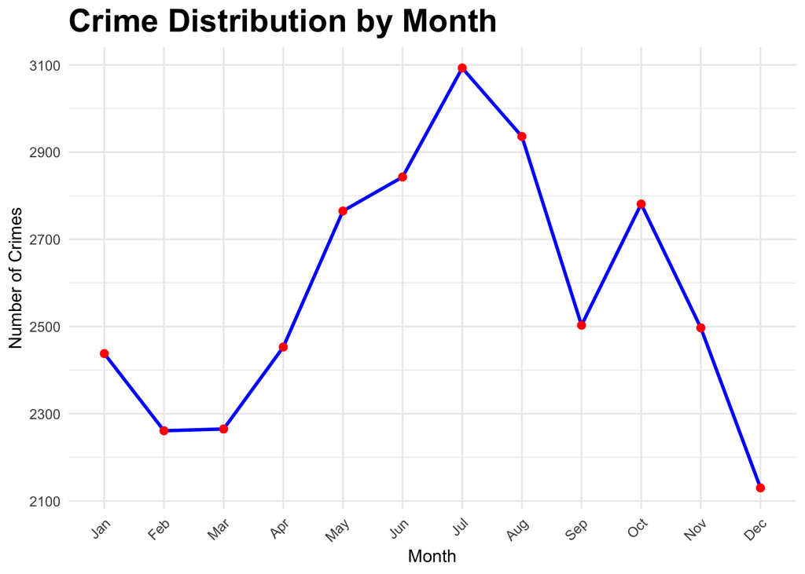

```r
crime_data_clean <- crime_data_clean %>%
  mutate(Month = factor(month(START_DATE, label = TRUE), levels = month.abb, ordered = TRUE))

crime_by_month <- crime_data_clean %>%
  group_by(Month) %>%
  summarise(Crime_Count = n()) %>%
  arrange(Month)

ggplot(crime_by_month, aes(x = Month, y = Crime_Count, group = 1)) +  # group = 1 for continuous line
  geom_line(color = 'blue', size = 1) +
  geom_point(color = 'red', size = 2) +
  labs(title = "Crime Distribution by Month", x = "Month", y = "Number of Crimes") +
  theme_minimal() +
  theme(plot.title = element_text(face = "bold", size = 20),
        axis.text.x = element_text(angle = 45, hjust = 1))
```

The line plot shows the distribution of crime by month in 2023. It is evident that July experienced the highest crime count of the year. Additionally, other warmer months, such as May, June, and August, also have relatively higher crime counts compared to other months. An unusually high spike in October is also notable. To gain further insights, we examined the crime counts by shift within each month.

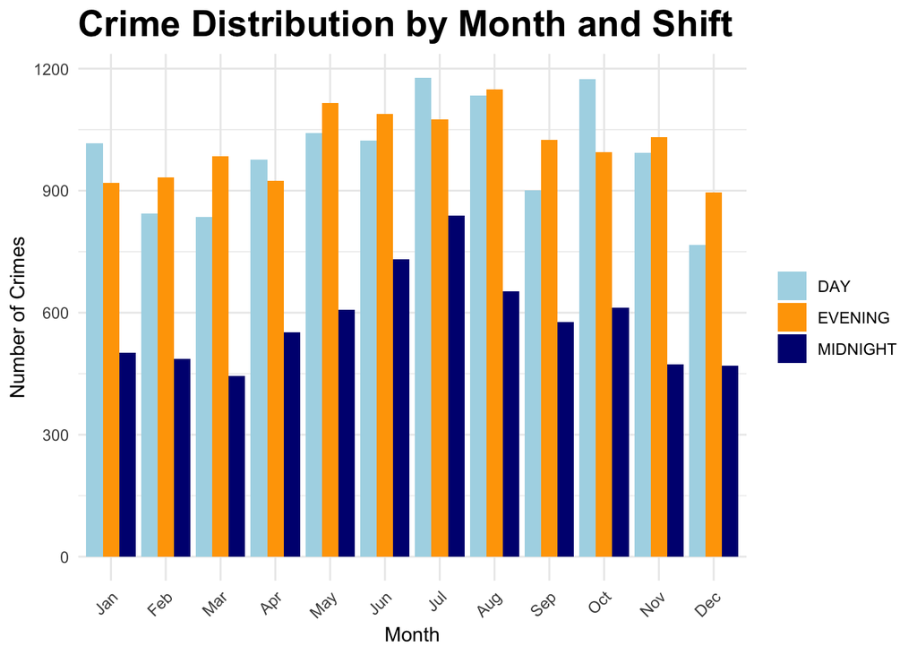

```r
ggplot(crime_data_clean, aes(x = Month, fill=SHIFT)) +
  geom_bar(position = 'dodge') +
  labs(title = "Crime Distribution by Month and Shift",
       x = "Month",
       y = "Number of Crimes") +
  scale_fill_manual(values = c("DAY" = "lightblue",
                               "EVENING" = "orange",
                               "MIDNIGHT" = "navy")) +
  theme_minimal() +
  theme(plot.title = element_text(face = "bold", size = 20),
        axis.text.x = element_text(angle = 45, hjust = 1),
        legend.title = element_blank())
```

The crime distribution showed only slight fluctuations during the `DAY` and `EVENING` shifts. However, crime incidents during the `MIDNIGHT` shift increased significantly during the warmer months and then declined as the weather cooled. This pattern could explain the higher crime rates in warmer months, as people are more likely to go out at night when temperatures are mild. Warmer weather often brings more social gatherings and outdoor activities, leading to increased interactions and potentially higher crime rates during nighttime hours.

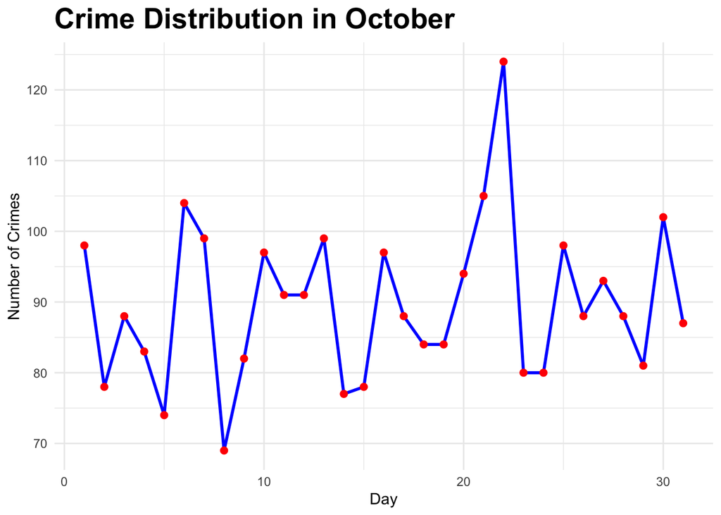

```r
crime_oct <- crime_data_clean %>%
  filter(Month == "Oct") %>%
  mutate(day  = day(START_DATE)) %>%
  group_by(day) %>%
  summarise(Crime_Count = n())

ggplot(crime_oct, aes(x = day, y=Crime_Count)) +
  geom_line(color = 'blue', size=1) +
  geom_point(color='red', size=2) +
  labs(title = "Crime Distribution in October",
       x = "Day",
       y = 'Number of Crimes') +
  theme_minimal() +
  theme(plot.title = element_text(face = "bold", size = 20))
```

To investigate the unusual spike in October’s crime rate, we examined crime distribution by day within the month and visualized it in a line plot. Initially, we considered Halloween as a potential cause for the increase, but the analysis showed no significant rise in crime near Halloween. Instead, the highest crime counts in October occurred on the 22nd, followed by the 21st.

During our exploration of events in Washington, DC, on October 21st and 22nd, 2023, we identified that the *Rock the Park DC WKNDR 2023* festival took place at **1315 I Street NW** on both days. Given that it was a tax-free dance music festival, we anticipate that the number of participants was substantial.

```r
crime_oct_22 <- crime_data_clean %>%
  filter(Month == "Oct" & day(START_DATE) == 22) %>%
  group_by(NEIGHBORHOOD_CLUSTER, NBH_NAMES) %>%
  summarise(crime_count = n()) %>%
  arrange(desc(crime_count))

xkabledplyhead(crime_oct_22, title = '5 Neighborhood Clusters with Highest Crimes on October 22nd')
```

5 Neighborhood Clusters with Highest Crimes on October 22nd

| NEIGHBORHOOD_CLUSTER | NBH_NAMES | crime_count |
| --- | --- | --- |
| Cluster 2 | Columbia Heights, Mt. Pleasant, Pleasant Plains, Park View | 12 |
| Cluster 3 | Howard University, Le Droit Park, Cardozo/Shaw | 12 |
| Cluster 18 | Brightwood Park, Crestwood, Petworth | 8 |
| Cluster 6 | Dupont Circle, Connecticut Avenue/K Street | 8 |
| Cluster 1 | Kalorama Heights, Adams Morgan, Lanier Heights | 7 |

```r
crime_oct_22_add <- crime_data_clean %>%
  filter(Month == "Oct" & day(START_DATE) == 22 & NEIGHBORHOOD_CLUSTER %in% c("Cluster 2",
                                                                            "Cluster 3",
                                                                            "Cluster 18",
                                                                            "Cluster 6",
                                                                            "Cluster 1")) %>%
  select(NEIGHBORHOOD_CLUSTER, BLOCK) %>%
  rename(CLUSTER = NEIGHBORHOOD_CLUSTER)

xkabledplyhead(crime_oct_22_add, 10, title = "Blocks in Highest Crime Clusters on Oct 22nd")
```

Blocks in Highest Crime Clusters on Oct 22nd

| CLUSTER | BLOCK |
| --- | --- |
| Cluster 18 | 1300 - 1399 BLOCK OF SHEPHERD STREET NW |
| Cluster 6 | 2000 - 2029 BLOCK OF FLORIDA AVENUE NW |
| Cluster 3 | 1921 - 1999 BLOCK OF 14TH STREET NW |
| Cluster 3 | 1400 - 1499 BLOCK OF W STREET NW |
| Cluster 18 | 400 - 499 BLOCK OF EMERSON STREET NW |
| Cluster 18 | 5300 - 5399 BLOCK OF 2ND STREET NW |
| Cluster 2 | 1400 - 1451 BLOCK OF IRVING STREET NW |
| Cluster 1 | 1730 - 1797 BLOCK OF LANIER PLACE NW |
| Cluster 2 | 1400 - 1499 BLOCK OF BELMONT STREET NW |
| Cluster 2 | 13TH STREET NW AND KENYON STREET NW |

We filtered the data to identify the top five neighborhood clusters with the highest crime rates and compiled their addresses. A total of 47 crimes occurred in these five neighborhoods, all located in the Northwest (NW) area of Washington, DC. Notably, the dance music festival also took place in the NW area, which could potentially explain the spike in crime on the 22nd.

## 4.2 Crime density by location

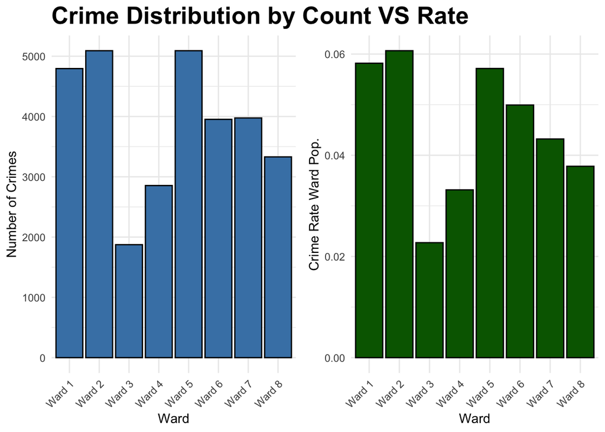

```r
ward_crime_p <- ggplot(crime_data_clean, aes(x = WARD)) +
  geom_bar(fill = "steelblue", color = 'black') +
  labs(title = "Crime Distribution by Count VS Rate", x = "Ward", y = "Number of Crimes") +
  theme_minimal() +
  theme(plot.title = element_text(face = "bold", size = 20),
        axis.text.x = element_text(angle = 45, hjust = 1))

ward_crime_counts <- crime_data_clean %>%
  group_by(WARD) %>%
  summarise(offense_count = n())

crime_per_capita <- ward_crime_counts %>%
  left_join(ward_df, by = c("WARD" = "NAMELSAD")) %>%
  mutate(crime_rate_per_capita = offense_count / total_population)


ward_crime_pop_p <- ggplot(crime_per_capita, aes(x = WARD, y = crime_rate_per_capita)) +
  geom_bar(stat = "identity", fill = "darkgreen", color = 'black') +
  labs(title = ' ', x = "Ward", y = "Crime Rate Ward Pop.") +
  theme_minimal() +
  theme(plot.title = element_text(face = "bold", size = 20),
        axis.text.x = element_text(angle = 45, hjust = 1))

grid.arrange(ward_crime_p, ward_crime_pop_p, ncol = 2)
```

In 2023, Wards 2 and 5 recorded the highest crime counts, followed closely by Ward 1. However, given the varying populations across wards, we opted to compare the crime rate per capita. This analysis reveals that Ward 2 has the highest crime rate, followed by Ward 1 and Ward 5.

To enhance visualization, we have mapped Washington, DC, displaying both crime counts and crime rates per capita by ward.

```r
# Retreiving DC wards' geographical dataset to plot maps
dc_wards <- state_legislative_districts(state = "dc")
dc_ward_crime <- dc_wards %>%
  left_join(ward_crime_counts, by = c("NAMELSAD" = "WARD"))
```

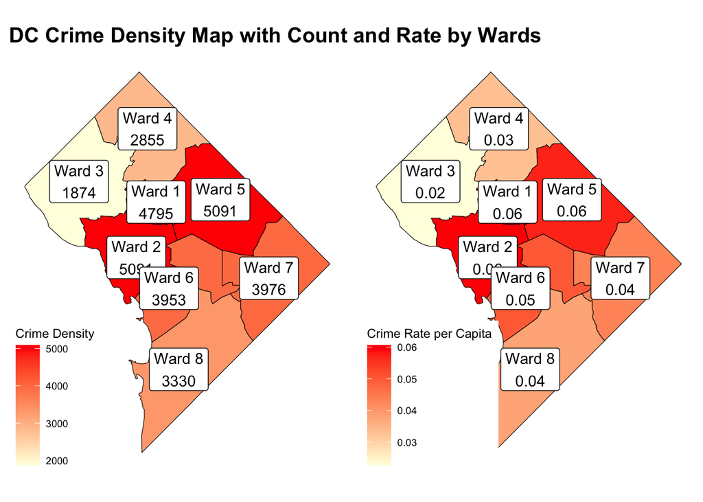

```r
ward_map <- ggplot(dc_ward_crime) +
  geom_sf(aes(fill = offense_count),
          color = "black") +
  geom_sf_label(aes(label = paste0(NAMELSAD,
                                   "\n",
                                   offense_count))) +
  scale_fill_gradient(low = "lightyellow", high = "red") +
  labs(title = 'DC Crime Density Map with Count and Rate by Wards',
       fill = "Crime Density") +
  theme_map() +
  theme(plot.title = element_text(face = "bold", size = 15))

dc_ward_crime_pop <- dc_wards %>%
  left_join(crime_per_capita, by = c("NAMELSAD" = "WARD"))

# Plotting the crime density map using crime per capita
ward_map_pop <- ggplot(dc_ward_crime_pop) +
  geom_sf(aes(fill = crime_rate_per_capita), color = "black") +  # Use crime_per_capita
  geom_sf_label(aes(label = paste0(NAMELSAD, "\n",
                                    round(crime_rate_per_capita, 2)))) +  # Round for better display
  scale_fill_gradient(low = "lightyellow", high = "red") +
  labs(title = ' ',
       fill = "Crime Rate per Capita") +
  theme_map() +
  theme(plot.title = element_text(face = "bold", size = 15))

grid.arrange(ward_map, ward_map_pop, ncol = 2)
```

To provide precise crime locations, we used the `LONGITUDE` and `LATITUDE` columns in our dataset to plot areas with higher and lower crime counts. Additionally, to examine the impact of police presence, we overlaid the 15 police stations in DC onto our crime density map.

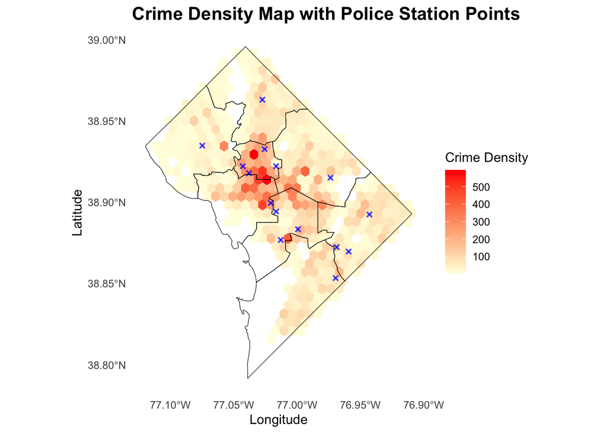

```r
ggplot() +
  geom_hex(data = crime_data_clean, aes(x = LONGITUDE, y = LATITUDE), bins = 30) +  # Crime density
  scale_fill_gradient(low = "lightyellow", high = "red") +  # Fill gradient for crime density
  geom_point(data = police_data, aes(x = LONGITUDE, y = LATITUDE), color = "blue", size = 1, stroke = 1, alpha = 0.7, shape = 4) +
  geom_sf(data = dc_wards, fill = NA, color = "black", size = 1.2) +
  labs(title = "Crime Density Map with Police Station Points",
       x = "Longitude",
       y = "Latitude",
       fill = 'Crime Density') +
  theme_minimal() +
  theme(plot.title = element_text(face = "bold", size = 15),
        panel.grid = element_blank())
```

Given the large area covered by each ward, we aimed to increase the precision of our analysis by grouping locations by neighborhood clusters and mapping the crime density accordingly.

```r
cluster_crime <- crime_data_clean %>%
  group_by(NEIGHBORHOOD_CLUSTER) %>%
  summarise(Crime_Count = n())

dc_clusters <- st_read("Neighborhood_Clusters.geojson") %>%
  left_join(cluster_crime, by = c("NAME" = "NEIGHBORHOOD_CLUSTER")) %>%
  mutate(cluster_number = gsub("\\D", "", NAME))
```

```r
dc_clusters$Crime_Count[is.na(dc_clusters$Crime_Count)] <- 0

highest_clusters <- dc_clusters %>%
  arrange(desc(Crime_Count)) %>%
  select(NAME, NBH_NAMES, Crime_Count) %>%
  rename(CLUSTER_NUMBER = NAME,
         NEIGHBORHOOD = NBH_NAMES,
         CRIME_COUNT = Crime_Count)
xkabledplyhead(highest_clusters, title = "Neighborhood Clusters with the Highest Crime Count")
```

Neighborhood Clusters with the Highest Crime Count

| CLUSTER_NUMBER | NEIGHBORHOOD | CRIME_COUNT | geometry |
| --- | --- | --- | --- |
| Cluster 2 | Columbia Heights, Mt. Pleasant, Pleasant Plains, Park View | 2229 | POLYGON ((-77 38.9, -77 38…. |
| Cluster 25 | Union Station, Stanton Park, Kingman Park | 2161 | POLYGON ((-77 38.9, -77 38…. |
| Cluster 3 | Howard University, Le Droit Park, Cardozo/Shaw | 1909 | POLYGON ((-77 38.9, -77 38…. |
| Cluster 8 | Downtown, Chinatown, Penn Quarters, Mount Vernon Square, North Capitol Street | 1906 | POLYGON ((-77 38.9, -77 38…. |
| Cluster 21 | Edgewood, Bloomingdale, Truxton Circle, Eckington | 1488 | POLYGON ((-77 38.9, -77 38…. |

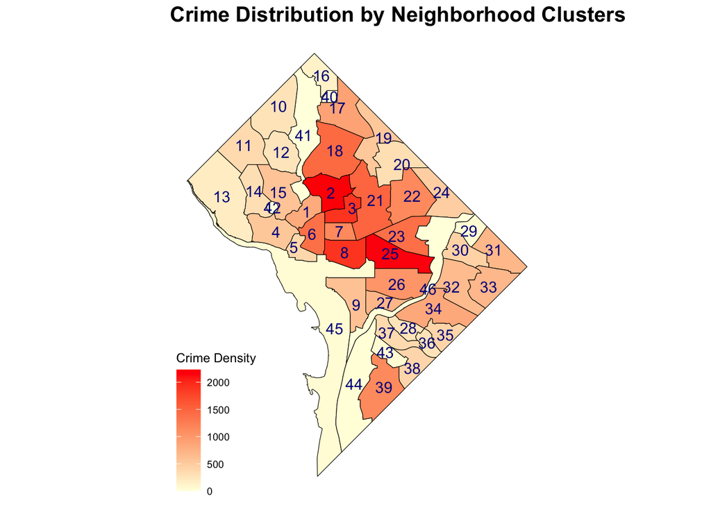

```r
ggplot(data = dc_clusters) +
  geom_sf(aes(fill = Crime_Count), color = "black", size = 0.5) +
  geom_sf_text(aes(label = cluster_number), color = 'darkblue') +
  scale_fill_gradient(low = "lightyellow", high = "red") +
  labs(title = "Crime Distribution by Neighborhood Clusters",
       x = 'Longitude',
       y = 'Latitude',
       fill = "Crime Density") +
  theme_map() +
  theme(plot.title = element_text(face = "bold", size = 15))
```

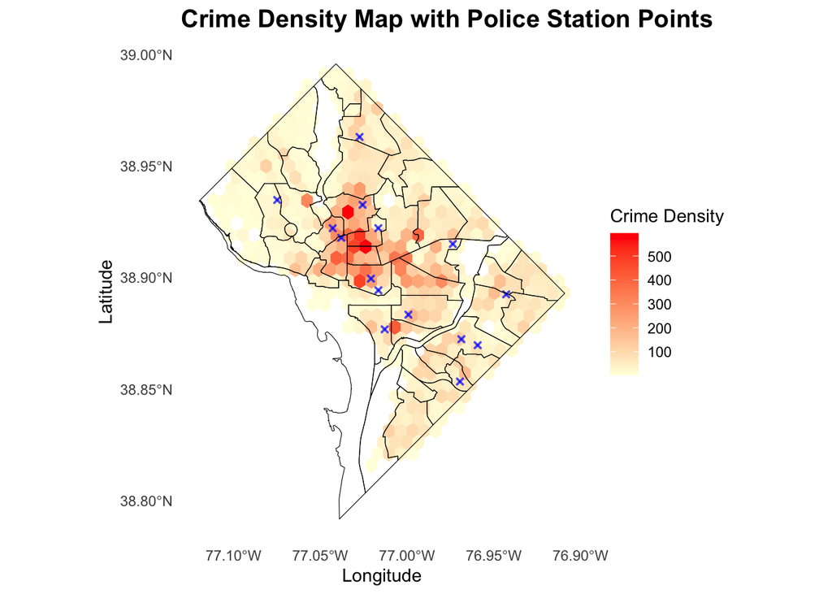

```r
ggplot() +
  geom_hex(data = crime_data_clean, aes(x = LONGITUDE, y = LATITUDE), bins = 30) +
  scale_fill_gradient(low = "lightyellow", high = "red") +  # Fill gradient for crime density
  geom_point(data = police_data, aes(x = LONGITUDE, y = LATITUDE), color = "blue", size = 1, stroke = 1, alpha = 0.7, shape = 4) +# Crime density
  geom_sf(data = dc_clusters, fill = NA, color = "black", size = 1.2) +
  labs(title = "Crime Density Map with Police Station Points",
       x = "Longitude",
       y = "Latitude",
       fill = 'Crime Density') +
  theme_minimal() +
  theme(plot.title = element_text(face = "bold", size = 15),
        panel.grid = element_blank())
```

Our analysis reveals that Neighborhood Cluster 2 (Columbia Heights, Mt. Pleasant, Pleasant Plains, Park View) has the highest crime count at 2229, followed by Neighborhood Cluster 25 (Union Station, Stanton Park, Kingman Park) with 2161 crimes. One potential factor contributing to these high crime counts could be the population size in these neighborhoods. However, due to limited data resources, we were unable to analyze neighborhood populations directly.

# 5 Statistical Test

## 5.1 Comparison Between the Crime Counts During Warm and Cool/Cold Months

We initially assumed that crime rates are higher in the warmer summer months compared to the cooler months of the year. For this analysis, we categorized May, June, July, and August as warmer months and the remaining months as cooler. Based on this assumption, we conducted a t-test to compare the mean crime counts between warmer and cooler months.  
H0: μWarm = μNot Warm  
H1: μWarm ≠ μNot Warm

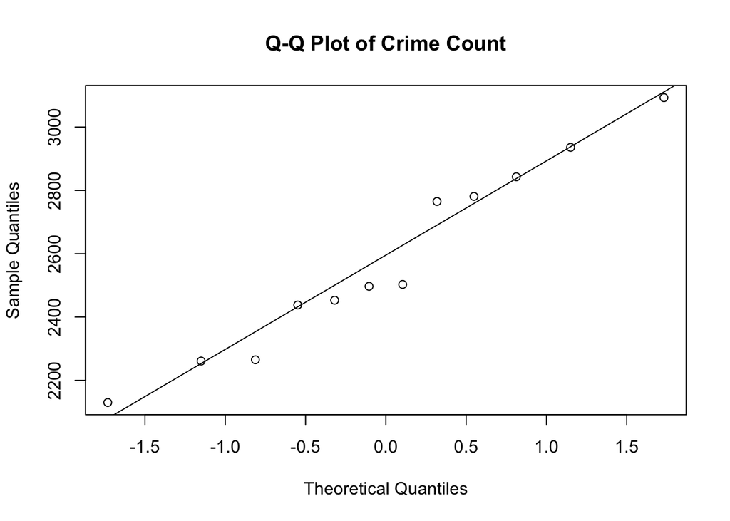

```r
# Comparing warm and cold/chill months
crime_by_month <- crime_by_month %>%
  mutate(Weather = ifelse(Month %in% c("May", "Jun", "Jul", "Aug"), "Warm", "Not Warm"))

# Checking the Normality of Crime Count
qqnorm(crime_by_month$Crime_Count, main = "Q-Q Plot of Crime Count")
qqline(crime_by_month$Crime_Count)
```

```r
# Shapiro-Wilk Test for Normality
shapiro.test(crime_by_month$Crime_Count)
```

```
##
##  Shapiro-Wilk normality test
##
## data:  crime_by_month$Crime_Count
## W = 1, p-value = 0.7
```

```r
# Perform T-Test
t_test_result <- t.test(Crime_Count ~ Weather, data = crime_by_month)
t_test_result
```

```
##
##  Welch Two Sample t-test
##
## data:  Crime_Count by Weather
## t = -5, df = 8, p-value = 0.001
## alternative hypothesis: true difference in means between group Not Warm and group Warm is not equal to 0
## 95 percent confidence interval:
##  -721 -265
## sample estimates:
## mean in group Not Warm     mean in group Warm
##                   2416                   2909
```

The t-test shows a statistically significant difference. The p-value is 0.001, which is much smaller than the significance level of 0.05. This indicates a statistically significant difference in crime counts between warm and cool/cold months. The 95% confidence interval for the difference in means ranges from -721 to -265, which does not include 0, reinforcing that the difference is statistically significant.

Since the p-value is very low, we can reject the null hypothesis that there is no difference in crime counts between warm and cool/cold months. The data suggests that crime counts are significantly higher during warmer months. This finding aligns with the common trend where warmer months often see higher crime rates, possibly due to increased outdoor activities and interactions.

## 5.2 Test on Association Between Month and Shift

Our second hypothesis posits an association between the month and the time of day when crimes occur. This hypothesis supports the assumption that during the warmer months, crime rates are higher during the midnight hours.

H0:Month and Shift are independent  
H1:Month and Shift are not independent

```r
table_month_shift <- table(crime_data_clean$Month, crime_data_clean$SHIFT)
chisq.test(table_month_shift)
```

```
##
##  Pearson's Chi-squared test
##
## data:  table_month_shift
## X-squared = 156, df = 22, p-value <2e-16
```

The results of the Pearson’s Chi-squared test provide strong evidence against the null hypothesis, which states that month and shift are independent. The test yielded a chi-squared statistic of 156 with 22 degrees of freedom and a p-value of less than 2e-16. This p-value is significantly lower than the conventional threshold of 0.05, indicating that there is a statistically significant association between the month and the time of day when crimes occur.

This result support our assumption that crime rates are higher during the midnight hours in the warmer months. This suggests that as temperatures rise, there may be an increase in criminal activity occurring late at night.

## 5.3 Police Presence Impact on Crime Rate

To analyze the impact of police presence, we conducted a correlation test and linear regression. We used the `LONGITUDE` and `LATITUDE` variables from both the crime dataset and the police station dataset to calculate the distance between each crime occurrence and the nearest police station. Subsequently, we grouped the results by `WARD` and calculated the average distance from crime points to police stations within each `WARD`. Following this analysis, we conducted the statistical tests.

```r
crime_coords <- as.matrix(crime_data_clean[, c("LONGITUDE", "LATITUDE")])
police_coords <- as.matrix(police_data[, c("LONGITUDE", "LATITUDE")])

# Calculate distance matrix between crime and police locations (in meters)
distance_matrix <- distm(crime_coords, police_coords, fun = distHaversine)

# Find nearest police station for each crime point
nearest_distance <- apply(distance_matrix, 1, min)

# Add distance to the crime dataset
crime_data_clean <- crime_data_clean %>%
  mutate(Nearest_Police_Distance = nearest_distance)

crime_counts <- crime_data_clean %>%
  group_by(WARD) %>%
  summarise(Crime_Count = n(), .groups = 'drop')


average_distances <- crime_data_clean %>%
  group_by(WARD) %>%
  summarise(Nearest_Police_Distance = mean(Nearest_Police_Distance, na.rm = TRUE), .groups = 'drop')

crime_summary <- left_join(crime_counts, average_distances, by = "WARD")

cor_test <- cor.test(crime_summary$Crime_Count, crime_summary$Nearest_Police_Distance)
print(cor_test)
```

```
##
##  Pearson's product-moment correlation
##
## data:  crime_summary$Crime_Count and crime_summary$Nearest_Police_Distance
## t = -1, df = 6, p-value = 0.3
## alternative hypothesis: true correlation is not equal to 0
## 95 percent confidence interval:
##  -0.880  0.361
## sample estimates:
##    cor
## -0.461
```

```r
# Linear model
model <- lm(Crime_Count ~ Nearest_Police_Distance, data = crime_summary)

# Summarize the model
summary(model)
```

```
##
## Call:
## lm(formula = Crime_Count ~ Nearest_Police_Distance, data = crime_summary)
##
## Residuals:
##     Min      1Q  Median      3Q     Max
## -1596.9  -429.7    20.4   468.5  1571.5
##
## Coefficients:
##                         Estimate Std. Error t value Pr(>|t|)
## (Intercept)              5605.03    1416.39    3.96   0.0075 **
## Nearest_Police_Distance    -1.29       1.01   -1.27   0.2501
## ---
## Signif. codes:  0 '***' 0.001 '**' 0.01 '*' 0.05 '.' 0.1 ' ' 1
##
## Residual standard error: 1100 on 6 degrees of freedom
## Multiple R-squared:  0.213,  Adjusted R-squared:  0.0815
## F-statistic: 1.62 on 1 and 6 DF,  p-value: 0.25
```

Our analysis aimed to evaluate the impact of police presence on crime rates by calculating the distance between crime occurrences and the nearest police stations in Washington, DC. Using correlation and linear regression tests, we found a Pearson correlation coefficient of -0.461, indicating a moderate negative correlation between crime counts and the average distance to police stations. However, the p-value of 0.3 suggests that this correlation is not statistically significant.

The linear regression model yielded an intercept of 5605.03, with a coefficient for Nearest_Police_Distance of -1.29, though this was also not statistically significant (p-value = 0.25). The model’s multiple R-squared value of 0.213 indicates that only about 21.3% of the variance in crime counts can be explained by the distance to the nearest police station.

While our initial hypothesis suggested that closer proximity to police stations might correlate with lower crime rates, the results did not support a significant relationship. It is important to note that other factors, such as neighborhood poverty, education, and the availability of entertainment amenities, may also significantly affect crime rates within the wards. Unfortunately, due to limited data resources, we were unable to conduct further research into the reasons behind the high crime rates observed.

# 6 Key Findings

**Crime Trends:** Our analysis indicates that theft is the predominant type of crime in Washington, DC. Seasonal variations were evident, with significant spikes in crime during the summer months, particularly in July, likely due to increased outdoor activities and population density.

**Impact of Events:** We observed a rise in crime rates in October 2023, coinciding with the “Rock the Park” event. This correlation highlights the need for enhanced security measures during large public gatherings, as such events can create opportunities for theft and other offenses.

**Local vs. Tourist Criminality:** An important consideration is whether the individuals committing these crimes are local residents or tourists. Given DC’s appeal as a tourist destination, understanding the demographics of offenders can inform targeted crime prevention strategies.

**Policy Implications and Future Research:** The findings underscore the need for targeted policing strategies and community engagement initiatives to address high theft rates and seasonal crime spikes. Future research should investigate the effectiveness of these strategies and explore the demographics of offenders to gain a clearer understanding of crime dynamics in Washington, DC.

**Limitations:** While this study provides valuable insights, it is important to acknowledge certain limitations. The analysis relies on reported crime data, which may not capture unreported incidents. Additionally, external factors such as changes in policing strategies or socio-economic conditions could influence crime rates and were not accounted for in this analysis. Our dataset also lacks information on the residency status of offenders, limiting our ability to assess whether crimes are committed by local residents or tourists. Future research should consider incorporating qualitative data to provide a more comprehensive view of the factors influencing crime.

# 7 Conclusion

Understanding these crime dynamics is crucial for residents and visitors alike. By offering insights into crime trends and the methods used in these offenses, we hope to empower individuals to make informed decisions about their safety and living environments. Moving forward, ongoing research into the demographics of offenders and the effectiveness of various crime prevention strategies will be vital in promoting a safer Washington, DC for everyone.